# Project: TMDb Movie Data

- Introduction
- Data Wrangling
- Exploratory Data Analysis
- Conclusions

## Introduction

In this project, I will investigate the TMDb movie dataset. This dataset contain 10.866 movies informations that was released between the years 1960 and 2015.

The dataset has the following collumns:

```
> id - The movie's ID.
> imdb_id - The movie's ID used in IMDB.
> popularity - A numeric quantity specifying the popularity of the movie.
> budget - The movie's budget in US dollars.
> revenue - The movie's revenue in US dollars.
> original_title - The title of the movie.
> cast - A list of actors who worked in movie.
> homepage - A link to the movie's homepage.
> director - The movie's director.
> tagline - The movie's tagline.
> keywords - The keywords or tags related to the movie.
> overview - A movie description.
> runtime - The running time of the movie in minutes.
> genres - The movie's genre (could be many genres listed).
> production_companies - The company that produced the movie.
> release_date - The movie's release date.
> vote_count - A numeric quantity specifying the count of votes the movie received.
> vote_average - The average rating the movie recieved.
> release_year - The year that the movie was released.
> budget_adj - The budget corrected by the 2010 inflation in US dollars .
> revenue_adj - The revenue corrected by the 2010 inflation in US dollars.
```

This project's main objective is to perform exploratory data analysis using pandas, numpy, seaborn and matplotlib python libraries.

### Questions

1. What are the highest revenue movies?
2. What is the average revenue of a movie over the years?
3. What are the highest budget movies?
4. What is the average budget of a movie over the years?
5. What are the highest profit movies?
6. What is the average profit of a movie over the years?
7. Which month had the most movies releases?
8. Which year had the most movies releases?
9. Which genres have the most movies released?
10. What is the average length of a movie over the years?
11. What kinds of properties are associated with movies that have high revenues?

```python
# Importing packages
import pandas as pd
import numpy as np
import matplotlib.pyplot as plt
%matplotlib inline
import seaborn as sns
sns.set_style('darkgrid')
```

## Data Wrangling

Let's load the dataset and verify if the data are cleanness and conciseness.

```python
# Loading the dataset
df = pd.read_csv("tmdb-movies.csv")

# Printing the dataset information
df.info()
```

```
<class 'pandas.core.frame.DataFrame'>
RangeIndex: 10866 entries, 0 to 10865
Data columns (total 21 columns):
id                      10866 non-null int64
imdb_id                 10856 non-null object
popularity              10866 non-null float64
budget                  10866 non-null int64
revenue                 10866 non-null int64
original_title          10866 non-null object
cast                    10790 non-null object
homepage                2936 non-null object
director                10822 non-null object
tagline                 8042 non-null object
keywords                9373 non-null object
overview                10862 non-null object
runtime                 10866 non-null int64
genres                  10843 non-null object
production_companies    9836 non-null object
release_date            10866 non-null object
vote_count              10866 non-null int64
vote_average            10866 non-null float64
release_year            10866 non-null int64
budget_adj              10866 non-null float64
revenue_adj             10866 non-null float64
dtypes: float64(4), int64(6), object(11)
memory usage: 1.7+ MB
```

#### Too many columns

We have initially 10.866 rows and 21 columns. There are some columns which we don't need in order to answer the questions. So in Data Cleaning section we will drop imdb_id, cast, homepage, tagline, keywords, overview, budget_adj and revenue_adj.

```python
# Verifying the data type of the release_date column
type(df['release_date'][0])
```

```
str
```

#### Incorrect data type

Note the incorrect data type defined for release_date column. We must change to date type to work more easily in Data Cleaning section.

```python
# Analysing the dataset brief statistic
df.describe()
```

|  | id | popularity | budget | revenue | runtime | vote_count | vote_average | release_year | budget_adj | revenue_adj |
| --- | --- | --- | --- | --- | --- | --- | --- | --- | --- | --- |
| count | 10866.000000 | 10866.000000 | 1.086600e+04 | 1.086600e+04 | 10866.000000 | 10866.000000 | 10866.000000 | 10866.000000 | 1.086600e+04 | 1.086600e+04 |
| mean | 66064.177434 | 0.646441 | 1.462570e+07 | 3.982332e+07 | 102.070863 | 217.389748 | 5.974922 | 2001.322658 | 1.755104e+07 | 5.136436e+07 |
| std | 92130.136561 | 1.000185 | 3.091321e+07 | 1.170035e+08 | 31.381405 | 575.619058 | 0.935142 | 12.812941 | 3.430616e+07 | 1.446325e+08 |
| min | 5.000000 | 0.000065 | 0.000000e+00 | 0.000000e+00 | 0.000000 | 10.000000 | 1.500000 | 1960.000000 | 0.000000e+00 | 0.000000e+00 |
| 25% | 10596.250000 | 0.207583 | 0.000000e+00 | 0.000000e+00 | 90.000000 | 17.000000 | 5.400000 | 1995.000000 | 0.000000e+00 | 0.000000e+00 |
| 50% | 20669.000000 | 0.383856 | 0.000000e+00 | 0.000000e+00 | 99.000000 | 38.000000 | 6.000000 | 2006.000000 | 0.000000e+00 | 0.000000e+00 |
| 75% | 75610.000000 | 0.713817 | 1.500000e+07 | 2.400000e+07 | 111.000000 | 145.750000 | 6.600000 | 2011.000000 | 2.085325e+07 | 3.369710e+07 |
| max | 417859.000000 | 32.985763 | 4.250000e+08 | 2.781506e+09 | 900.000000 | 9767.000000 | 9.200000 | 2015.000000 | 4.250000e+08 | 2.827124e+09 |

```python
# Counting the number of rows that have zero in revenue
df[df["revenue"] == 0].count()
```

```
id                      6016
imdb_id                 6006
popularity              6016
budget                  6016
revenue                 6016
original_title          6016
cast                    5945
homepage                1271
director                5973
tagline                 3656
keywords                4758
overview                6012
runtime                 6016
genres                  5993
production_companies    5082
release_date            6016
vote_count              6016
vote_average            6016
release_year            6016
budget_adj              6016
revenue_adj             6016
dtype: int64
```

```python
# Counting the number of rows that have zero in budget
df[df["budget"] == 0].count()
```

```
id                      5696
imdb_id                 5687
popularity              5696
budget                  5696
revenue                 5696
original_title          5696
cast                    5631
homepage                1229
director                5656
tagline                 3488
keywords                4534
overview                5692
runtime                 5696
genres                  5674
production_companies    4802
release_date            5696
vote_count              5696
vote_average            5696
release_year            5696
budget_adj              5696
revenue_adj             5696
dtype: int64
```

#### Too many zeros in revenue and budget columns

The revenue and the budget columns have a lot of zeros. These zero can bias our analysis and comparison. To correct this we could categorize the movies according to the budget into AAA, AA, and A. That way we would apply the average budget according to the movie (AAA = large budget; AA = medium; A = indie movie). But to do that we would need to study every movie that is without budget and define what AAA is each year. Another solution may be to remove the rows that are zeros in budget and revenue. However there are too many lines (6016 movies with zero in revenue; 5696 movies with zero in budget).

For now, let's just replace the zeros for NaN (Not a Number) in Data Cleaning section and continue with the analysis.

```python
# Checking the null values
df.isnull().sum()
```

```
id                         0
imdb_id                   10
popularity                 0
budget                     0
revenue                    0
original_title             0
cast                      76
homepage                7930
director                  44
tagline                 2824
keywords                1493
overview                   4
runtime                    0
genres                    23
production_companies    1030
release_date               0
vote_count                 0
vote_average               0
release_year               0
budget_adj                 0
revenue_adj                0
dtype: int64
```

23 movies genres are null values.

```python
# Checking the duplicated values
sum(df.duplicated())
```

```
1
```

```python
# What movie is duplicated
df.loc[df.duplicated() == True]
```

|  | id | imdb_id | popularity | budget | revenue | original_title | cast | homepage | director | tagline | ... | overview | runtime | genres | production_companies | release_date | vote_count | vote_average | release_year | budget_adj | revenue_adj |
| --- | --- | --- | --- | --- | --- | --- | --- | --- | --- | --- | --- | --- | --- | --- | --- | --- | --- | --- | --- | --- | --- |
| 2090 | 42194 | tt0411951 | 0.59643 | 30000000 | 967000 | TEKKEN | Jon Foo\|Kelly Overton\|Cary-Hiroyuki Tagawa\|Ian... | NaN | Dwight H. Little | Survival is no game | ... | In the year of 2039, after World Wars destroy ... | 92 | Crime\|Drama\|Action\|Thriller\|Science Fiction | Namco\|Light Song Films | 3/20/10 | 110 | 5.0 | 2010 | 30000000.0 | 967000.0 |

1 rows × 21 columns

#### Duplicated data

One movie (Tekken) is duplictaed in dataset and must be corrected in Data Cleaning section.

### Data Cleaning

Let's correct all inconsistencies we found in dataset.

#### 1. Too many columns

#### 2. Incorrect data type

#### 3. Too many zeros in revenue and budget columns

#### 4. Duplicated data

#### 1. Too many columns

```python
# Removing some columns
df.drop(["imdb_id", "cast", "homepage", "tagline", "keywords", "overview", "budget_adj", "revenue_adj"],
        axis = 1, inplace = True )
```

```python
# Printing the column labels in the dataset
for i, v in enumerate(df.columns):
    print(i, v)
```

```
0 id
1 popularity
2 budget
3 revenue
4 original_title
5 director
6 runtime
7 genres
8 production_companies
9 release_date
10 vote_count
11 vote_average
12 release_year
```

```python
#  Getting the current shape of the dataset
df.shape
```

```
(10866, 13)
```

Now we have 10.866 rows and 13 columns. We dropped the columns: imdb_id, cast, homepage, tagline, keywords, overview, budget_adj and revenue_adj. **Too many columns corrected**

#### 2. Incorrect data type

```python
# Changing the data type of release_date
df["release_date"] = pd.to_datetime(df["release_date"])
```

```python
# Checking the data types of all columns
df.dtypes
```

```
id                               int64
popularity                     float64
budget                           int64
revenue                          int64
original_title                  object
director                        object
runtime                          int64
genres                          object
production_companies            object
release_date            datetime64[ns]
vote_count                       int64
vote_average                   float64
release_year                     int64
dtype: object
```

```python
# Let's check the first 3 rows
df.head(3)
```

|  | id | popularity | budget | revenue | original_title | director | runtime | genres | production_companies | release_date | vote_count | vote_average | release_year |
| --- | --- | --- | --- | --- | --- | --- | --- | --- | --- | --- | --- | --- | --- |
| 0 | 135397 | 32.985763 | 150000000 | 1513528810 | Jurassic World | Colin Trevorrow | 124 | Action\|Adventure\|Science Fiction\|Thriller | Universal Studios\|Amblin Entertainment\|Legenda... | 2015-06-09 | 5562 | 6.5 | 2015 |
| 1 | 76341 | 28.419936 | 150000000 | 378436354 | Mad Max: Fury Road | George Miller | 120 | Action\|Adventure\|Science Fiction\|Thriller | Village Roadshow Pictures\|Kennedy Miller Produ... | 2015-05-13 | 6185 | 7.1 | 2015 |
| 2 | 262500 | 13.112507 | 110000000 | 295238201 | Insurgent | Robert Schwentke | 119 | Adventure\|Science Fiction\|Thriller | Summit Entertainment\|Mandeville Films\|Red Wago... | 2015-03-18 | 2480 | 6.3 | 2015 |

The data type of release_date was changed. **Incorrect data type corrected**.

#### 3. Too many zeros in revenue and budget columns

```python
# Replacing the zeros in revenue and budget for NaN
df[["revenue", "budget"]] = df[["revenue", "budget"]].replace(0,np.NAN)
```

```python
# Analysing the statistic after the applying NaN values
df.describe()
```

|  | id | popularity | budget | revenue | runtime | vote_count | vote_average | release_year |
| --- | --- | --- | --- | --- | --- | --- | --- | --- |
| count | 10866.000000 | 10866.000000 | 5.170000e+03 | 4.850000e+03 | 10866.000000 | 10866.000000 | 10866.000000 | 10866.000000 |
| mean | 66064.177434 | 0.646441 | 3.073943e+07 | 8.922066e+07 | 102.070863 | 217.389748 | 5.974922 | 2001.322658 |
| std | 92130.136561 | 1.000185 | 3.890065e+07 | 1.620684e+08 | 31.381405 | 575.619058 | 0.935142 | 12.812941 |
| min | 5.000000 | 0.000065 | 1.000000e+00 | 2.000000e+00 | 0.000000 | 10.000000 | 1.500000 | 1960.000000 |
| 25% | 10596.250000 | 0.207583 | 6.000000e+06 | 7.708081e+06 | 90.000000 | 17.000000 | 5.400000 | 1995.000000 |
| 50% | 20669.000000 | 0.383856 | 1.700000e+07 | 3.182654e+07 | 99.000000 | 38.000000 | 6.000000 | 2006.000000 |
| 75% | 75610.000000 | 0.713817 | 4.000000e+07 | 9.991823e+07 | 111.000000 | 145.750000 | 6.600000 | 2011.000000 |
| max | 417859.000000 | 32.985763 | 4.250000e+08 | 2.781506e+09 | 900.000000 | 9767.000000 | 9.200000 | 2015.000000 |

```python
# Checking the NaN values in revenue
np.isnan(df["revenue"]).sum()
```

```
6016
```

```python
# Checking the NaN values in budget
np.isnan(df["budget"]).sum()
```

```
5696
```

The zeros in revenue and budget were replaced for NaN values. **Too many zeros in revenue and budget columns correted**.

#### 4. Duplicated data

```python
# Removing the duplicated data
df.drop_duplicates(inplace = True)
```

```python
# Checking the duplicated values
sum(df.duplicated())
```

```
0
```

```python
#  Getting the current shape of the dataset
df.shape
```

```
(10865, 13)
```

The movie duplicated (Tekken) was removed. **Duplicated data corrected**.

## Exploratory Data Analysis

### Research Question 1: What are the highest revenue movies?

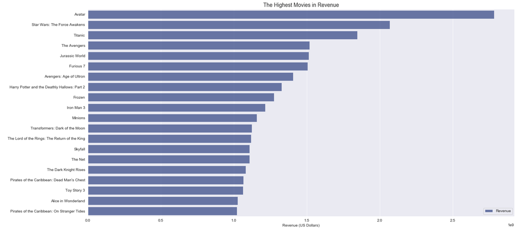

```python
# Constructing a DataFrame to filter, sort and cut the 20 movies by revenue
df_revenue = pd.DataFrame(df["revenue"].sort_values(ascending = False))[:20]
df_revenue["original_title"] = df["original_title"]

# Setting up the figure
plt.figure(figsize = (20,10))
sns.set_color_codes("dark")

# Plotting
sns.barplot(x = "revenue", y = "original_title", data = df_revenue, color = "b", label = "Revenue", alpha = 0.6)

# Setting up the title and axes label
plt.title("The Highest Movies in Revenue", fontsize = 14)
plt.xlabel("Revenue (US Dollars)", fontsize = 10)
plt.ylabel(" ")
plt.legend();
```

### Research Question 2: What is the average revenue of a movie over the years?

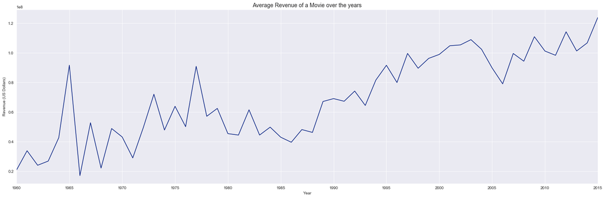

```python
# Finding the mean revenue of each movie with group by
data = df.groupby("release_year")["revenue"].mean()

# Setting up the figure
plt.figure(figsize = (26,8))
sns.set_color_codes("dark")

# Plotting
data.plot(xticks = np.arange(1960, 2016, 5), color = "b")

# Setting up the title and axes label
plt.title("Average Revenue of a Movie over the years", fontsize = 14)
plt.xlabel("Year", fontsize = 10)
plt.ylabel("Revenue (US Dollars)", fontsize = 10);
```

### Research Question 3: What are the highest budget movies?

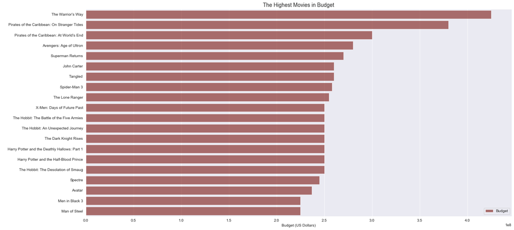

```python
# Constructing a DataFrame to filter, sort and cut the 20 movies by budget
df_budget = pd.DataFrame(df["budget"].sort_values(ascending = False))[:20]
df_budget["original_title"] = df["original_title"]

# Setting up the figure
plt.figure(figsize = (20,10))
sns.set_color_codes("dark")

# Plotting
sns.barplot(x = "budget", y = "original_title", data = df_budget, color = "r", label = "Budget", alpha = 0.6)

# Setting up the title and axes label
plt.title("The Highest Movies in Budget", fontsize = 14)
plt.xlabel("Budget (US Dollars)", fontsize = 10)
plt.ylabel(" ")
plt.legend();
```

### Research Question 4: What is the average budget of a movie over the years?

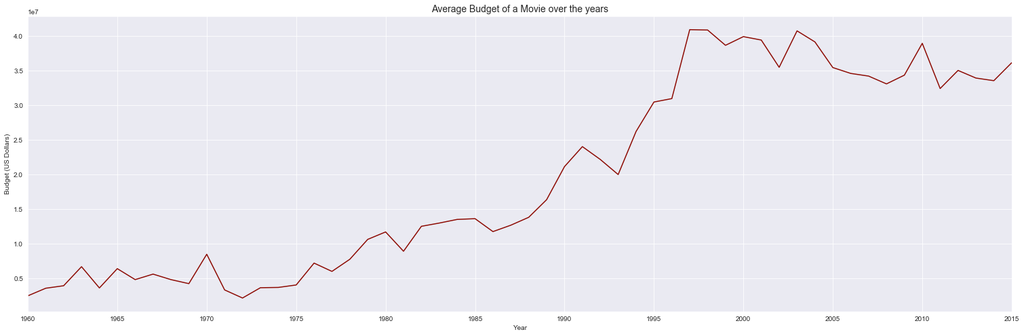

```python
# Finding the mean budget of each movie with group by
data = df.groupby("release_year")["budget"].mean()

# Setting up the figure
plt.figure(figsize = (26,8))
sns.set_color_codes("dark")

# Plotting
data.plot(xticks = np.arange(1960, 2016, 5), color = "r")

# Setting up the title and axes label
plt.title("Average Budget of a Movie over the years", fontsize = 14)
plt.xlabel("Year", fontsize = 10)
plt.ylabel("Budget (US Dollars)", fontsize = 10);
```

### Research Question 5: What are the highest profit movies?

In order to calculate the highest profit movies, we need to create a new column for each movie. Let's call this new column "profit". Let's define the profit of a movie like the total revenue minus the budget.

```python
# Creating the new column
df["profit"] = df["revenue"] - df["budget"]
```

```python
# Printing the dataset information
df.info()
```

```
<class 'pandas.core.frame.DataFrame'>
Int64Index: 10865 entries, 0 to 10865
Data columns (total 14 columns):
id                      10865 non-null int64
popularity              10865 non-null float64
budget                  5169 non-null float64
revenue                 4849 non-null float64
original_title          10865 non-null object
director                10821 non-null object
runtime                 10865 non-null int64
genres                  10842 non-null object
production_companies    9835 non-null object
release_date            10865 non-null datetime64[ns]
vote_count              10865 non-null int64
vote_average            10865 non-null float64
release_year            10865 non-null int64
profit                  3854 non-null float64
dtypes: datetime64[ns](1), float64(5), int64(4), object(4)
memory usage: 1.6+ MB
```

```python
# Checking the NaN values in profit
np.isnan(df["profit"]).sum()
```

```
7011
```

The movies with NaN values in revenue and budget resulted NaN values in profit too.

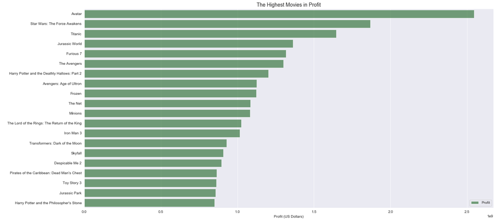

```python
# Constructing a DataFrame to filter, sort and cut the 20 movies by profit
df_profit = pd.DataFrame(df["profit"].sort_values(ascending = False))[:20]
df_profit["original_title"] = df["original_title"]

# Setting up the figure
plt.figure(figsize = (20,10))
sns.set_color_codes("dark")

# Plotting
sns.barplot(x = "profit", y = "original_title", data = df_profit, color = "g", label = "Profit", alpha = 0.6)

# Setting up the title and axes label
plt.title("The Highest Movies in Profit", fontsize = 14)
plt.xlabel("Profit (US Dollars)", fontsize = 10)
plt.ylabel(" ")
plt.legend();
```

### Research Question 6: What is the average profit of a movie over the years?

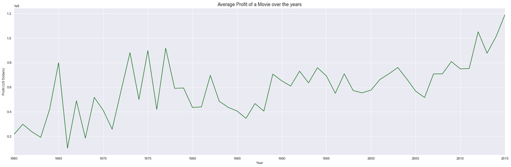

```python
# Finding the mean profit of each movie with group by
data = df.groupby("release_year")["profit"].mean()

# Setting up the figure
plt.figure(figsize = (26,8))
sns.set_color_codes("dark")

# Plotting
data.plot(xticks = np.arange(1960, 2016, 5), color = "g")

# Setting up the title and axes label
plt.title("Average Profit of a Movie over the years", fontsize = 14)
plt.xlabel("Year", fontsize = 10)
plt.ylabel("Profit (US Dollars)", fontsize = 10);
```

### Research Question 7: Which month had the most movies releases?

In order to compare easily the months that movies were released, we need to create another column. The information that we want could be extracted in release_date column, forming the new release_month column.

```python
# Creating a new column
# Using strftime returns the string representation of the Period, in case %B => full month name
df["release_month"] = df["release_date"].dt.strftime("%B")
```

```python
# Printing the dataset information
df.info()
```

```
<class 'pandas.core.frame.DataFrame'>
Int64Index: 10865 entries, 0 to 10865
Data columns (total 15 columns):
id                      10865 non-null int64
popularity              10865 non-null float64
budget                  5169 non-null float64
revenue                 4849 non-null float64
original_title          10865 non-null object
director                10821 non-null object
runtime                 10865 non-null int64
genres                  10842 non-null object
production_companies    9835 non-null object
release_date            10865 non-null datetime64[ns]
vote_count              10865 non-null int64
vote_average            10865 non-null float64
release_year            10865 non-null int64
profit                  3854 non-null float64
release_month           10865 non-null object
dtypes: datetime64[ns](1), float64(5), int64(4), object(5)
memory usage: 1.6+ MB
```

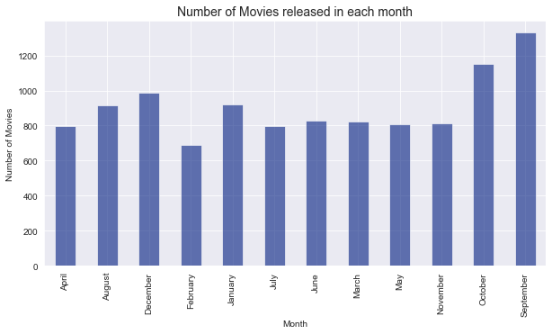

```python
# Counting the movies released in each month
month_resume = df.groupby("release_month")["original_title"].count()

# Setting up the figure
plt.figure(figsize = (10,5))
sns.set_color_codes("dark")

# Plotting
month_resume.plot.bar(color = "b", alpha = 0.6)

# Setting up the title and axes label
plt.title("Number of Movies released in each month", fontsize = 14)
plt.xlabel("Month", fontsize = 10)
plt.ylabel("Number of Movies", fontsize = 10);
```

September was the month with more movies released (1.331 movies), followed by October (1.153 movies) and December (985 movies).

### Research Question 8: Which year had the most movies releases?

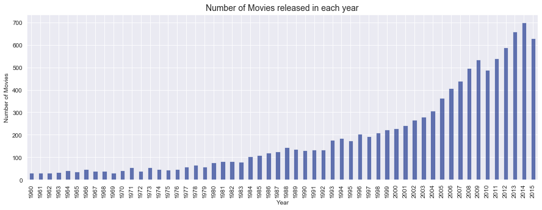

```python
# Counting the movies released in each year
year_resume = df.groupby("release_year")["original_title"].count()

# Setting up the figure
plt.figure(figsize = (15,5))
sns.set_color_codes("dark")

# Plotting
year_resume.plot.bar(color = "b", alpha = 0.6)

# Setting up the title and axes label
plt.title("Number of Movies released in each year", fontsize = 14)
plt.xlabel("Year", fontsize = 10)
plt.ylabel("Number of Movies", fontsize = 10);
```

The 2014 was the year with more movies released (700 movies), followed by 2013 (659 movies) and 2015 (629 movies).

### Research Question 9: Which genres have the most movies released?

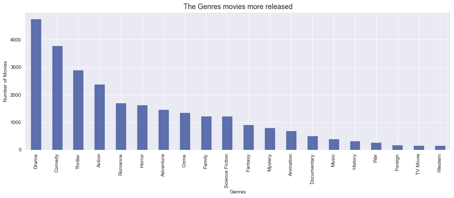

```python
# Concatenating genres from all movies given the separator => |
df_genres = df["genres"].str.cat(sep = "|")

# Splitting the total value and store
df_genres = pd.Series(df_genres.split("|"))

# Counting the genres
genres_resume = df_genres.value_counts(ascending = False)

# Setting up the figure
plt.figure(figsize = (15,5))
sns.set_color_codes("dark")

# Plotting
genres_resume.plot.bar(color = "b", alpha = 0.6)

# Setting up the title and axes label
plt.title("The Genres movies more released", fontsize = 14)
plt.xlabel("Genres", fontsize = 10)
plt.ylabel("Number of Movies", fontsize = 10);
```

The Drama was the genre with more movies released (4.760 movies), followed by Comedy (3.793 movies) and Thriller (2.907 movies). Remember that a movie can be classified with more than one genre.

### Research Question 10: What is the average length of a movie over the years?

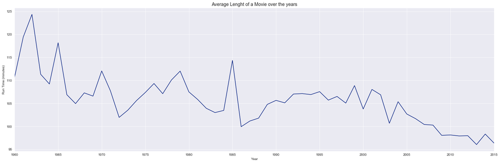

```python
# Finding the mean length of each movie with group by
data = df.groupby("release_year")["runtime"].mean()

# Setting up the figure
plt.figure(figsize = (26,8))
sns.set_color_codes("dark")

# Plotting
data.plot(xticks = np.arange(1960, 2016, 5), color = "b")

# Setting up the title and axes label
plt.title("Average Lenght of a Movie over the years", fontsize = 14)
plt.xlabel("Year", fontsize = 10)
plt.ylabel("Run Time (minutes)", fontsize = 10);
```

### Research Question 11: What kinds of properties are associated with movies that have high revenues?

```python
# Let's check the correlation between the columns
df.corr()
```

|  | id | popularity | budget | revenue | runtime | vote_count | vote_average | release_year | profit |
| --- | --- | --- | --- | --- | --- | --- | --- | --- | --- |
| id | 1.000000 | -0.014351 | -0.075766 | -0.040848 | -0.088368 | -0.035555 | -0.058391 | 0.511393 | 0.003934 |
| popularity | -0.014351 | 1.000000 | 0.479961 | 0.629305 | 0.139032 | 0.800828 | 0.209517 | 0.089806 | 0.596201 |
| budget | -0.075766 | 0.479961 | 1.000000 | 0.688556 | 0.265575 | 0.580050 | 0.092014 | 0.215402 | 0.526818 |
| revenue | -0.040848 | 0.629305 | 0.688556 | 1.000000 | 0.237748 | 0.764113 | 0.206847 | 0.121388 | 0.979133 |
| runtime | -0.088368 | 0.139032 | 0.265575 | 0.237748 | 1.000000 | 0.163273 | 0.156813 | -0.117187 | 0.220238 |
| vote_count | -0.035555 | 0.800828 | 0.580050 | 0.764113 | 0.163273 | 1.000000 | 0.253818 | 0.107962 | 0.728348 |
| vote_average | -0.058391 | 0.209517 | 0.092014 | 0.206847 | 0.156813 | 0.253818 | 1.000000 | -0.117576 | 0.259435 |
| release_year | 0.511393 | 0.089806 | 0.215402 | 0.121388 | -0.117187 | 0.107962 | -0.117576 | 1.000000 | 0.087971 |
| profit | 0.003934 | 0.596201 | 0.526818 | 0.979133 | 0.220238 | 0.728348 | 0.259435 | 0.087971 | 1.000000 |

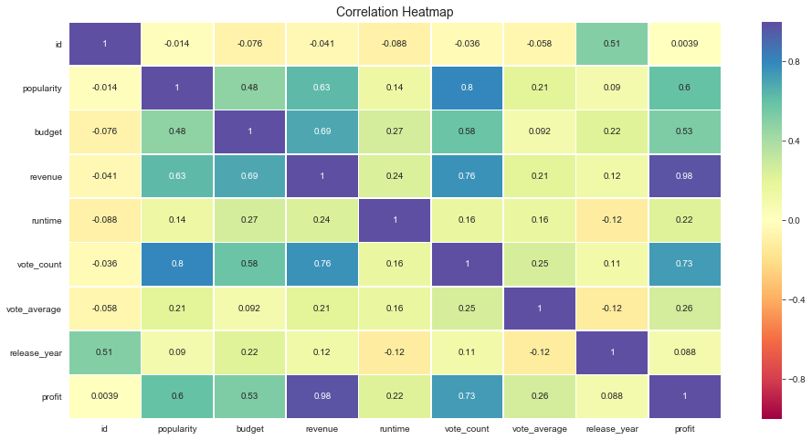

```python
# Setting up the figure
plt.figure(figsize = (16,8))

# Plotting the Heatmap
sns.heatmap(df.corr(), annot = True, cmap = "Spectral", linewidths = .5, vmin = -1, vmax = 1)

# Setting up the title
plt.title("Correlation Heatmap", fontsize = 14);
```

The heat map above shows in the revenue line the correlation between the revenue and the others columns.

We can see a higher positive correlation between revenue and profit (0,98), vote_count (0,76), budget (0,69) and popularity (0,63).

A lower positive correlation can be noted between revenue and runtime (0,24), vote_average (0,21) and release_year (0,12).

A weak negative correlation can be seen between revenue and id (-0,041).

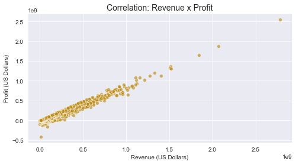

```python
# Setting up the figure
plt.figure(figsize = (8,4))
sns.set_color_codes("dark")

# Plotting the scatterplot
sns.scatterplot(x = "revenue", y = "profit", data = df, color = "y", alpha = 0.6)

# Setting up the title and axes label
plt.title("Correlation: Revenue x Profit", fontsize = 14)
plt.xlabel("Revenue (US Dollars)")
plt.ylabel("Profit (US Dollars)");
```

Proportionally, the higher the revenue, the higher the profit will be. It's logical.

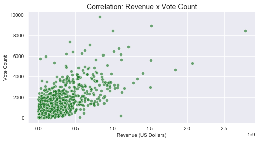

```python
# Setting up the figure
plt.figure(figsize = (8,4))
sns.set_color_codes("dark")

# Plotting the scatterplot
sns.scatterplot(x = "revenue", y = "vote_count", data = df, color = "g", alpha = 0.6)

# Setting up the title and axes label
plt.title("Correlation: Revenue x Vote Count", fontsize = 14)
plt.xlabel("Revenue (US Dollars)")
plt.ylabel("Vote Count");
```

The more popular votes (vote_count) the movie gets, the bigger word of mouth marketing will be. The bigger general public interest results in a bigger revenue.

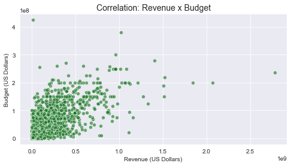

```python
# Setting up the figure
plt.figure(figsize = (8,4))
sns.set_color_codes("dark")

# Plotting the scatterplot
sns.scatterplot(x = "revenue", y = "budget", data = df, color = "g", alpha = 0.6)

# Setting up the title and axes label
plt.title("Correlation: Revenue x Budget", fontsize = 14)
plt.xlabel("Revenue (US Dollars)")
plt.ylabel("Budget (US Dollars)");
```

We can consider that if a company has approved a high budget for making a movie, it expects to receive high revenue. However, this does not always happen. It is a high bet.

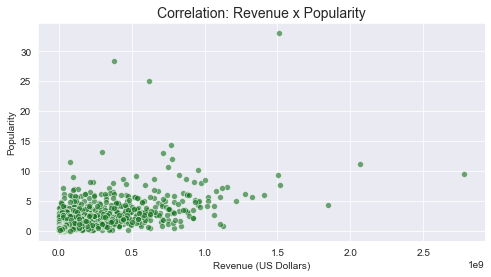

```python
# Setting up the figure
plt.figure(figsize = (8,4))
sns.set_color_codes("dark")

# Plotting the scatterplot
sns.scatterplot(x = "revenue", y = "popularity", data = df, color = "g", alpha = 0.6)

# Setting up the title and axes label
plt.title("Correlation: Revenue x Popularity", fontsize = 14)
plt.xlabel("Revenue (US Dollars)")
plt.ylabel("Popularity");
```

The movie's popularity reflects the public's interest in it, resulting in higher revenue.

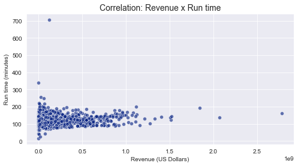

```python
# Setting up the figure
plt.figure(figsize = (8,4))
sns.set_color_codes("dark")

# Plotting the scatterplot
sns.scatterplot(x = "revenue", y = "runtime", data = df, color = "b", alpha = 0.6)

# Setting up the title and axes label
plt.title("Correlation: Revenue x Run time", fontsize = 14)
plt.xlabel("Revenue (US Dollars)")
plt.ylabel("Run time (minutes)");
```

The relationship between the recipe and the length of a movie is hard to explain. But the commercially perfect movie must have an appropriate length, neither too long nor too short.

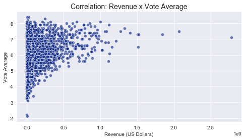

```python
# Setting up the figure
plt.figure(figsize = (8,4))
sns.set_color_codes("dark")

# Plotting the scatterplot
sns.scatterplot(x = "revenue", y = "vote_average", data = df, color = "b", alpha = 0.6)

# Setting up the title and axes label
plt.title("Correlation: Revenue x Vote Average", fontsize = 14)
plt.xlabel("Revenue (US Dollars)")
plt.ylabel("Vote Average");
```

If the popular vote (vote_count) has a strong correlation with revenue, the average of the votes has a weak correlation. We can think of indie movies that are well received by critics, but do not arouse interest in the general public, resulting in low revenue.

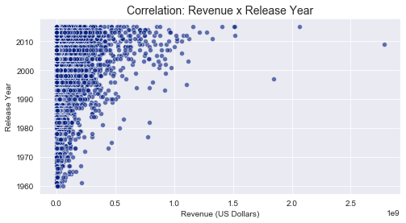

```python
# Setting up the figure
plt.figure(figsize = (8,4))
sns.set_color_codes("dark")

# Plotting the scatterplot
sns.scatterplot(x = "revenue", y = "release_year", data = df, color = "b", alpha = 0.6)

# Setting up the title and axes label
plt.title("Correlation: Revenue x Release Year", fontsize = 14)
plt.xlabel("Revenue (US Dollars)")
plt.ylabel("Release Year");
```

Another relationship hard to explain. The correlation between revenue and release year is obtuse. In the current years, we have a lot more movies coming out compared to the 1960s. With more movies coming out the chance that one of them gets a high revenue is higher.

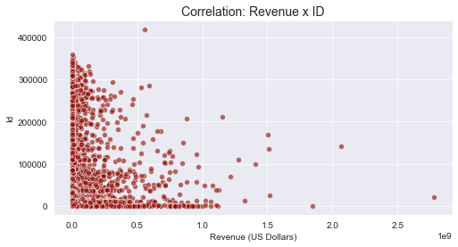

```python
# Setting up the figure
plt.figure(figsize = (8,4))
sns.set_color_codes("dark")

# Plotting the scatterplot
sns.scatterplot(x = "revenue", y = "id", data = df, color = "r", alpha = 0.6)

# Setting up the title and axes label
plt.title("Correlation: Revenue x ID", fontsize = 14)
plt.xlabel("Revenue (US Dollars)")
plt.ylabel("Id");
```

The negative correlation is a relationship between two variables whereby they move in opposite directions. Revenue and ID show a weak negative correlation.

## Conclusions

> 1. What are the highest revenue movies?

>    The highest revenue movies are: Avatar, Star Wars: The Force Awakens, Titanic, The Avengers, ...
> 2. What is the average revenue of a movie over the years?

>    The average revenue of a movie over the years has significantly increasing. Despite severe oscillations in 1965 and 1977. Reaching the top in 2015.
> 3. What are the highest budget movies?

>    The highest budget movies are: The Warrior's Way, Pirates of the Caribbean: On Stranger Tides, Pirates of the Caribbean: At World's End, Avengers: Age of Ultron, ...
> 4. What is the average budget of a movie over the years?

>    The average budget of a movie over the years had increased strong until 1997, stabilizing until 1998, when started decreased. In 2003 and 2010 the budget increased quickly again, but fell again, keeping the downward trend.
> 5. What are the highest profit movies?

>    The highest profit movies are: Avatar, Star Wars: The Force Awakens, Titanic, Jurassic World, ...
> 6. What is the average profit of a movie over the years?

>    The average profit of a movie over the years grew strongly in line with revenue. The chart shows severe oscillations with a growing tendency, reaching the top in 2015.
> 7. Which month had the most movies releases?

>    September was the month with more movies released (1.331 movies), followed by October (1.153 movies) and December (985 movies).
> 8. Which year had the most movies releases?

>    The 2014 was the year with more movies released (700 movies), followed by 2013 (659 movies) and 2015 (629 movies).
> 9. Which genres have the most movies released?

>    The Drama was the genre with more movies released (4.760 movies), followed by Comedy (3.793 movies) and Thriller (2.907 movies). Remember that a movie can be classified with more than one genre.
> 10. What is the average length of a movie over the years?

>     The average length of a movie has been falling over the years.
> 11. What kinds of properties are associated with movies that have high revenues?

>     The heat map shows in the revenue line the correlation between the revenue and the others columns.

>     We can see a higher positive correlation between revenue and profit (0,98), vote_count (0,76), budget (0,69) and popularity (0,63).

>     A lower positive correlation can be noted between revenue and runtime (0,24), vote_average (0,21) and release_year (0,12).

>     A weak negative correlation can be seen between revenue and id (-0,041).